# Manipulacion de datos espaciales

Pablo Gomez-Vazquez

En este tutorial introduciremos a manipulacion de datos espaciales en R.  
Existen dos formatos principales para manipular datos espaciales en R:

- **SpatialDataFrame** de la libreria `sp`: Este formato fue de los primeros introducidos para cargar datos en R, por lo tanto existen muchas librerias que dependen de este formato (i.e. `raster`, `spdep`, `spstat`).
- **Simple features** de la libreria `sf`: Esta libreria fue desarrollada mas recientemente, esta libreria fue creada para ser mas intuitiva con otros paquetes de tidyverse. este tipo de objetos tiene sopporte para el formato de pipelines (`%>%`). El problema de esta libreria es que dado a ue es mas reciente, aldunas librerias no son compatibles con este formato.

Aprender a trabajar con los dos formatos tiene sus ventajas, para manipulacion de los datos `sf` es mas intuitivo y poderoso, pero para analisis espacial `sp` es mas robusto.

En este curso usaremos `sf` principalmente, pero habra situaciones en las que tengamos que cambiar de un formato a otro.

Para este curso, se ha desarrollado el paquete en R `STNet` que incluye los datos y algunas funciones que usaremos.  
Para instalar la libreria tenemos que usar el paquete `devtools`, si no esta instalado habra que instalarlo.

```r
# Cargamos las librerias
library(STNet)
library(sf)
# cargamos los datos
data("PRRS")
data("SwinePrem")
# Cargamos los datos espaciales
Io <- st_read(system.file("data/Io.shp", package = "STNet"))
```

La funcion `st_read()` automaticamente muestra algo de informacion sobre nuestro shapefile, pero podemos ver mas detalles cuando lo imprimimos desde la consola:

```r
Io
```

```
## Simple feature collection with 99 features and 2 fields
## geometry type:  POLYGON
## dimension:      XY
## bbox:           xmin: -96.63567 ymin: 40.37454 xmax: -90.13931 ymax: 43.50465
## epsg (SRID):    4326
## proj4string:    +proj=longlat +datum=WGS84 +no_defs
## First 10 features:
##    NAME_1     NAME_2                       geometry
## 1    Iowa      Adair POLYGON ((-94.24274 41.5030...
## 2    Iowa      Adams POLYGON ((-94.4728 41.1566,...
## 3    Iowa  Allamakee POLYGON ((-91.20658 43.4250...
## 4    Iowa  Appanoose POLYGON ((-92.71506 40.5902...
## 5    Iowa    Audubon POLYGON ((-94.74762 41.8609...
## 6    Iowa     Benton POLYGON ((-91.83191 42.2986...
## 7    Iowa Black Hawk POLYGON ((-92.29958 42.2974...
## 8    Iowa      Boone POLYGON ((-93.70088 42.2079...
## 9    Iowa     Bremer POLYGON ((-92.08252 42.9061...
## 10   Iowa   Buchanan POLYGON ((-91.60603 42.6437...
```

El resultado muestra:  
- `geometry type`: El tipo de shapefiles (ya sea point, lines o polygons).  
- `dimension` Dimensiones usadas en el shapefile.  
- `bbox`: La extension de nuestros datos.  
- `epsg (SRID)`: La proyeccion en formato *EPSG* (El cual es un codigo estandarizado para describir la proyeccion).  
- `proj4string`: La proyeccion en formato proj4string.  
- Los 10 primeros elementos.

Los objetos `sf` son escencialmente un `data.frame` con informacion extra sobre la geometria y proyeccion. Podemos obtener la geometria unicamente usando el operador `$` o la funcion `st_geometry()` y despues mostrarla en una figura

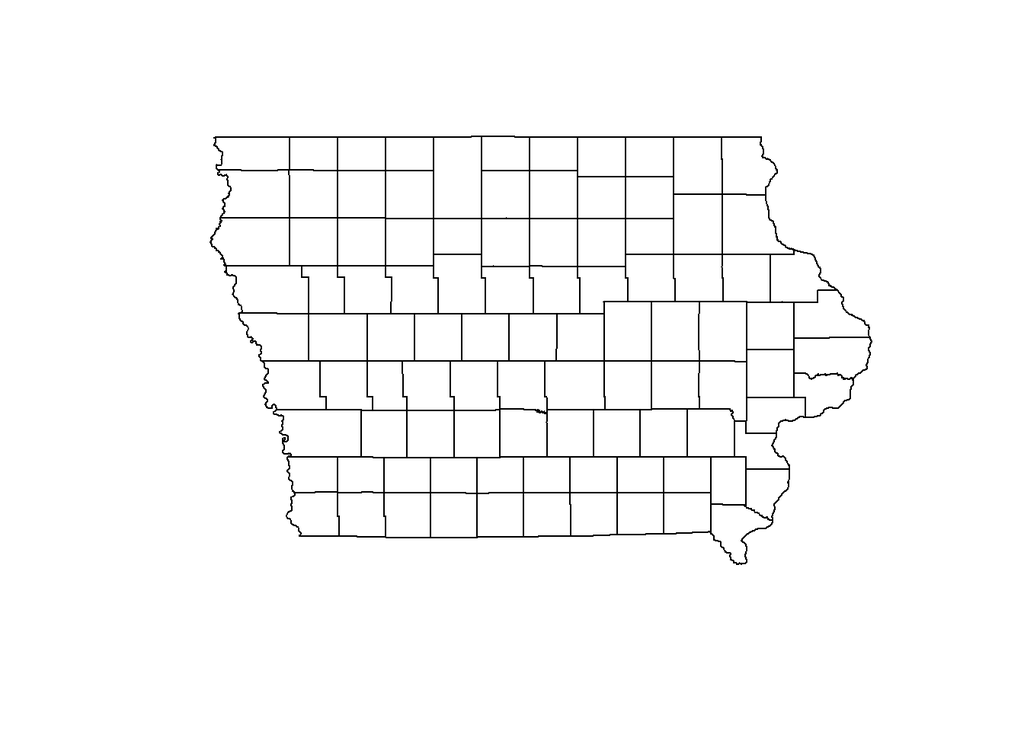

```r
plot(Io$geometry)
```